# Lab 6: More data transformation

## `gather()`

The chart we want to make display data for just Santa Clara county, so we should use `dplyr`’s `filter` to get a new dataset with just the observations from Santa Clara:

```r
# filter for just Santa Clara County
df_county <- df_levels %>% filter(County == "Santa Clara County")
```

Let’s make a line plot of `D0` against `Date`:

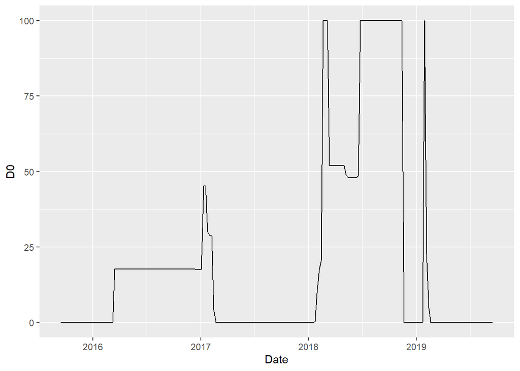

```r
ggplot(data = df_county) +
    geom_line(mapping = aes(x = Date, y = D0))
```

To make an area plot instead, replace `geom_line` with `geom_area`:

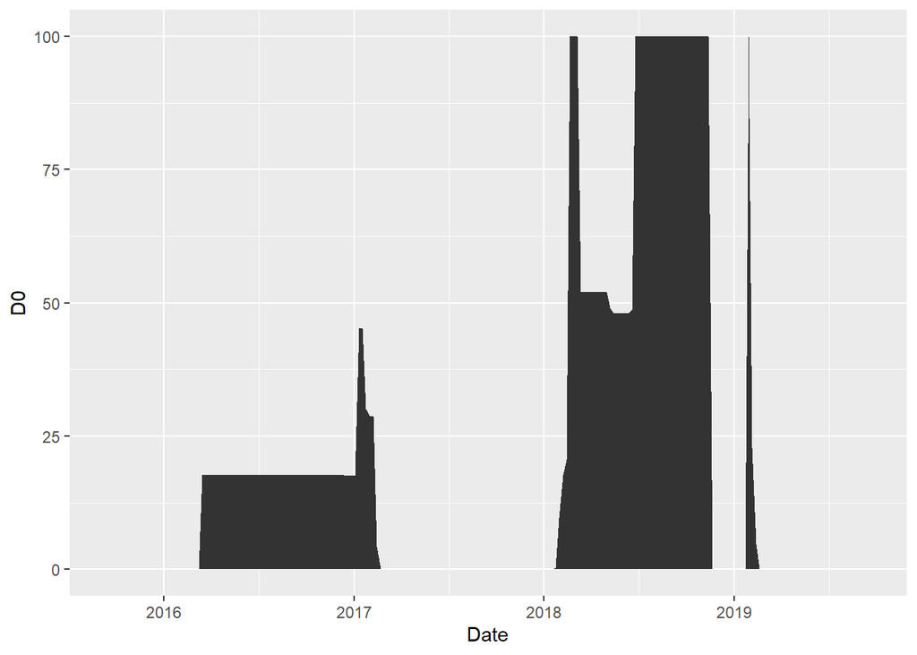

```r
ggplot(data = df_county) +
    geom_area(mapping = aes(x = Date, y = D0))
```

How can we plot `D0` and `D1` against `Date`? We could try this:

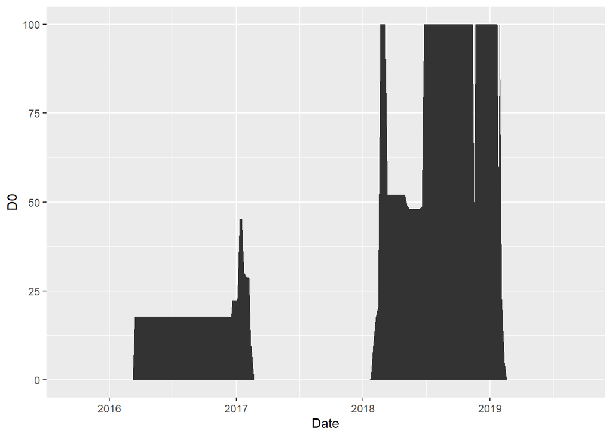

```r
ggplot(data = df_county) +
    geom_area(mapping = aes(x = Date, y = D0)) +
    geom_area(mapping = aes(x = Date, y = D1))
```

There are a number of issues with this approach:

- It doesn’t scale. To display `D0` to `D4`, we need 3 more lines of code. What if there were 10 drought levels instead?
  - Both areas are filled in with black and are stacked on top of each other, so we can’t tell the difference between the two.
- The y-axis reads `D0` even though the values plotted are for `D0` and `D1`.

The reason we are facing this issue is because the values of drought level are column names. We need to reorganize the dataset such that there is a `Drought level` column with values `D0` to `D4`, and a corresponding `Percent of land area` which gives the percent of land area in that level of drought (In Hadley Wickham’s terminology, the original dataset is not “tidy” and we have to make it so.) We can use `tidyr`’s `gather` function to accomplish this.

```r
# gather drought levels
df_county <- df_county %>% gather(D0:D4, key = "Drought level",
                                  value = "Percent of land area")
```

Now we can easily plot `D0` to `D4` on the same chart (because our column names have spaces in them, we need to surround them with backticks (`) so that R interprets the code properly):

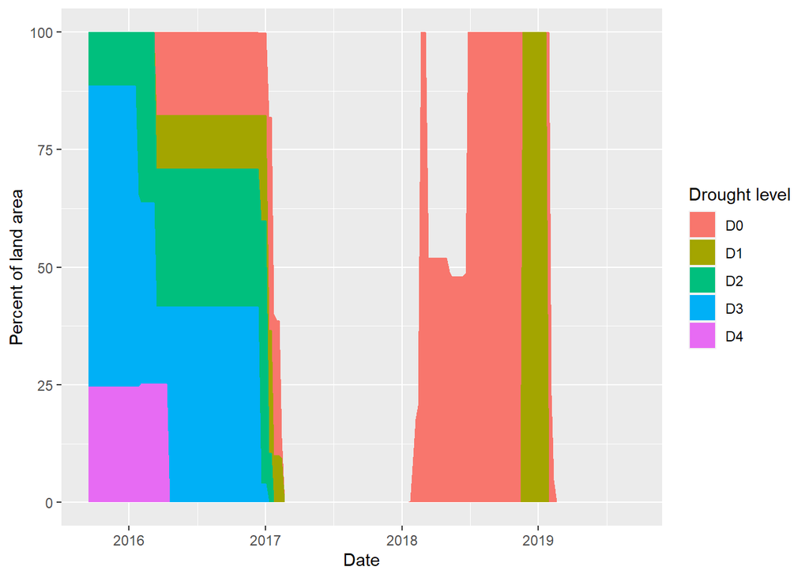

```r
# make area plot
ggplot(data = df_county) +
    geom_area(mapping = aes(x = Date, y = `Percent of land area`,
                            fill = `Drought level`))
```

Let’s use `scale_fill_brewer` to make the area colors more theme-appropriate, and add a title:

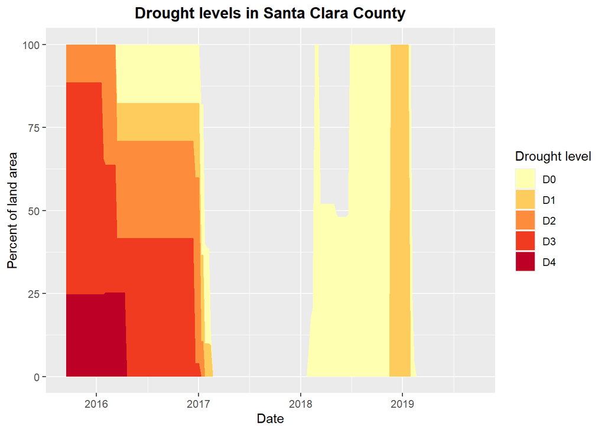

```r
# make area plot
ggplot(data = df_county) +
    geom_area(mapping = aes(x = Date, y = `Percent of land area`,
                            fill = `Drought level`)) +
    labs(title = "Drought levels in Santa Clara County") +
    scale_fill_brewer(palette = "YlOrRd") +
    theme(plot.title = element_text(face = "bold", hjust = 0.5))
```

(`scale_fill_brewer` works in the same way as `scale_color_brewer`, except that it refers to the “fill” aesthetic rather than the “color” aesthetic. Both of these functions work for discrete variables; for continuous variables, use `scale_fill_distiller` and `scale_color_distiller` instead.)

## Scripting for reuse

The code below demonstrates this approach. (It assumes that we have already computed the data frame `df_levels`.) Note that the changes are actually quite minimal. For the plot, we made use of the `paste()` function to make the plot title dynamic.

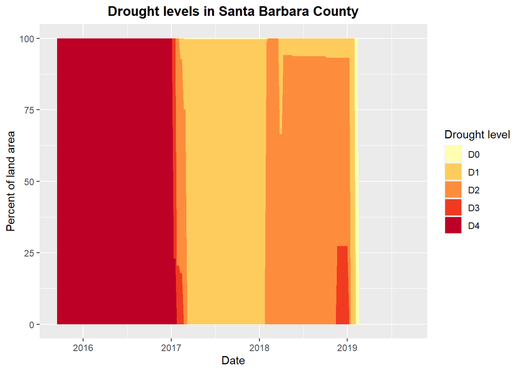

```r
county <- "Santa Barbara County"

# filter for the county, reshape data
df_county <- df_levels %>%
    filter(County == county) %>%
    gather(D0:D4, key = "Drought level",
           value = "Percent of land area")

# make area plot
ggplot(data = df_county) +
    geom_area(mapping = aes(x = Date, y = `Percent of land area`,
                            fill = `Drought level`)) +
    labs(title = paste("Drought levels in", county)) +
    scale_fill_brewer(palette = "YlOrRd") +
    theme(plot.title = element_text(face = "bold", hjust = 0.5))
```

### Functions practice

1. Create a function that will return the sum of 2 integers.
2. Create a function that given a data frame will return the name of the columns.
3. Create a function that given a vector will return the mean and the standard deviation.
4. Create a function that applies standardization to a vector, i.e. subtracts the mean and divides by standard deviation.
5. Create a function that applies some linear transformation to a vector, i.e. given $a$, $b$ it will subtract $a$ from all of the elements and divide by $b$.
6. Set the default value of $a = 0$ and $b = 1$, i.e. no transformation is applied.
7. Create a function that given a vector will return the last element in the vector.

### More `dplyr` practice

Below are some exercise for you to practice your `dplyr` skills. All of them use the `df_levels` dataset as the starting point. Solutions are in the section below.

1. Select the rows with D4 being 100.
2. Which counties experienced D4 being 100 on 2015-10-20?
3. Which counties experienced D4 being 100 on 2015-10-20? Give just the county names.
4. Which counties experienced 100% land area in D4 at any time? (Hint: instead of n_distinct, try distinct.)
5. Select rows with date “2018-09-18” and return the entries in descending order of D0.
6. Which county experienced the most number of weeks with 100% land area in D4?

### Functions practice (solutions)

1. Create a function that will return the sum of 2 integers.

```r
add <- function(x, y){
    x+y
}
```

2. Create a function that given a data frame will return the name of the columns.

```r
col_names <- function(df){
    names(df)
}
```

3. Create a function that given a vector will return the mean and the standard deviation.

```r
mean_and_sd <- function(x){
    list(mean = mean(x), sd = sd(x))
}
```

4. Create a function that applies standardization to a vector, i.e. subtracts the mean and divides by standard deviation.

```r
standardize <- function(x){
    (x - mean(x))/sd(x)
}
```

5. Create a function that applies some linear transformation to a vector, i.e. given $a$, $b$ it will subtract $a$ from all of the elements and divide by $b$.

```r
transform <- function(x, a, b){
    (x - a)/b
}
```

6. Set the default value of $a = 0$ and $b = 1$, i.e. no transformation is applied.

```r
transform <- function(x, a = 0, b = 1){
    (x - a)/b
}
```

7. Create a function that given a vector will return the last element in the vector.

```r
last_element <- function(x){
    index <- length(x)
    x[index]
}
```

### More `dplyr` practice (solutions)

1. Select the rows with D4 being 100.

```r
df_levels %>% filter(D4 == 100)
```

2. Which counties experienced D4 being 100 on 2015-10-20?

```r
df_levels %>% filter(D4 == 100 & Date == "2015-10-20")
```

```
##                  County       Date D0 D1 D2 D3  D4 Drought
## 1         Alpine County 2015-10-20  0  0  0  0 100     100
## 2         Amador County 2015-10-20  0  0  0  0 100     100
## 3      Calaveras County 2015-10-20  0  0  0  0 100     100
## 4      El Dorado County 2015-10-20  0  0  0  0 100     100
## 5         Fresno County 2015-10-20  0  0  0  0 100     100
## 6          Kings County 2015-10-20  0  0  0  0 100     100
## 7         Madera County 2015-10-20  0  0  0  0 100     100
## 8       Mariposa County 2015-10-20  0  0  0  0 100     100
## 9         Merced County 2015-10-20  0  0  0  0 100     100
## 10          Mono County 2015-10-20  0  0  0  0 100     100
## 11        Nevada County 2015-10-20  0  0  0  0 100     100
## 12        Placer County 2015-10-20  0  0  0  0 100     100
## 13        Plumas County 2015-10-20  0  0  0  0 100     100
## 14   San Joaquin County 2015-10-20  0  0  0  0 100     100
## 15 Santa Barbara County 2015-10-20  0  0  0  0 100     100
## 16        Sierra County 2015-10-20  0  0  0  0 100     100
## 17    Stanislaus County 2015-10-20  0  0  0  0 100     100
## 18        Sutter County 2015-10-20  0  0  0  0 100     100
## 19        Tulare County 2015-10-20  0  0  0  0 100     100
## 20      Tuolumne County 2015-10-20  0  0  0  0 100     100
## 21       Ventura County 2015-10-20  0  0  0  0 100     100
## 22          Yuba County 2015-10-20  0  0  0  0 100     100
```

3. Which counties experienced D4 being 100 on 2015-10-20? Give just the county names.

```r
df_levels %>% filter(D4 == 100 & Date == "2015-10-20") %>%
    select(County)
```

```
##                  County
## 1         Alpine County
## 2         Amador County
## 3      Calaveras County
## 4      El Dorado County
## 5         Fresno County
## 6          Kings County
## 7         Madera County
## 8       Mariposa County
## 9         Merced County
## 10          Mono County
## 11        Nevada County
## 12        Placer County
## 13        Plumas County
## 14   San Joaquin County
## 15 Santa Barbara County
## 16        Sierra County
## 17    Stanislaus County
## 18        Sutter County
## 19        Tulare County
## 20      Tuolumne County
## 21       Ventura County
## 22          Yuba County
```

4. Which counties experienced 100% land area in D4 at any time? (Hint: instead of n_distinct, try distinct.)

```r
df_levels %>% filter(D4 == 100) %>%
    distinct(County)
```

```
##                  County
## 1         Alpine County
## 2         Amador County
## 3      Calaveras County
## 4      El Dorado County
## 5         Fresno County
## 6          Kings County
## 7         Madera County
## 8       Mariposa County
## 9         Merced County
## 10          Mono County
## 11        Nevada County
## 12        Placer County
## 13        Plumas County
## 14   San Joaquin County
## 15 Santa Barbara County
## 16        Sierra County
## 17    Stanislaus County
## 18        Sutter County
## 19        Tulare County
## 20      Tuolumne County
## 21       Ventura County
## 22          Yuba County
```

5. Select rows with date “2018-09-18” and return the entries in descending order of D0.

```r
df_levels %>% filter(Date == "2018-09-18") %>% arrange(desc(D0))
```

6. Which county experienced the most number of weeks with 100% land area in D4?

   ```r
   df_levels %>%
   filter(D4 == 100) %>%
   group_by(County) %>%
   summarize(count = n()) %>%
   arrange(desc(count))
   ```

   ```
   ## # A tibble: 22 x 2
   ##    County               count
   ##    <chr>                <int>
   ##  1 Santa Barbara County    69
   ##  2 Ventura County          69
   ##  3 Fresno County           31
   ##  4 Kings County            31
   ##  5 Madera County           31
   ##  6 Mariposa County         31
   ##  7 Merced County           31
   ##  8 San Joaquin County      31
   ##  9 Stanislaus County       31
   ## 10 Tulare County           31
   ## # ... with 12 more rows
   ```